# POTENTIAL TALENTS

## CONTEXT

The client is a talent sourcing and management company who are interested in finding talented individuals for sourcing these candidates to tech companies. They are facing three main challenges:

- To understand what the role is very well to fill in a role, this requires understanding the tech company's requirements and what they are looking for in a potential candidate.
- To understand what factors make a candidate shine for a given role that the tech company is searchinh for.
- To find those paricularly talented individuals is another key challenge.

#### CURRENT SCENARIO

- The nature of the taks required a lot of human labour and is fully of manual operations.
- Presently, the client is semi-automated, sourcing is not a concern, but finding the right candidate is the main concern.
- The client uses a keyword-based search method to find the right candidate for a given role, such as "*Full-Stack Software Engineer*" or "*Aspiring Human Resources*".

## DATA DESCRIPTION

The data comes from the client's own sourcing efforts. Any field/attritbute that could directly reveal personal details have been removed and have been assigned a unique identifier for each candidate.

### ATTRIBUTES

- **id** : unique identifier for candidate (numeric)
- **job_title** : job title for candidate (text)
- **location** : geographical location for candidate (text)
- **connections**: number of connections candidate has, 500+ means over 500 (text)

**Output (desired target)**:

- **fit** - how fit the candidate is for the role? (numeric, probability between 0-1)

**Keywords**: "*Aspiring human resources*" or "*seeking human resources*"

## PROJECT GOALS

- To predict how fit the candidate is based on the provided information (i.e. the target variable fit)
- Build a ranking based robust system, in this case an unsupervised learning approach, to rank the fitting candidates based on a fitness which is our success metric.
- Once an initial ranking is achieved, re-rank the candidates, because, for instance, the 1st candidate might not be the right fit, but the 7th might be.
- Determine a cut-off point that would work for other roles without losing high potential candidates.
- Automate the process in such a way that it prevents the human bias as much as possible.

## METHODOLOGY

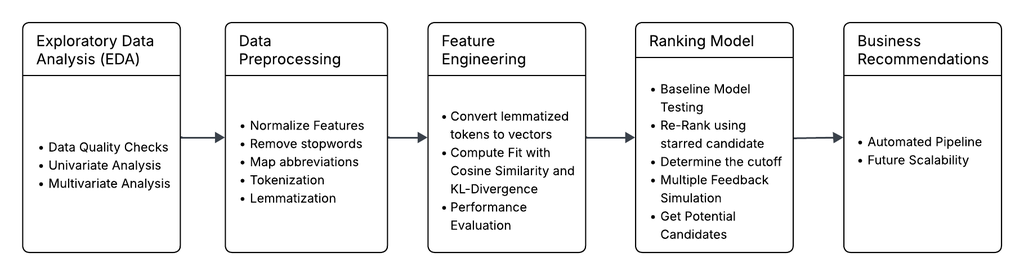

```python
# import data analysis libraries
import numpy as np
import pandas as pd
import math


# ignore warnings
import warnings
warnings.filterwarnings('ignore')

import re
import string
import spacy
from nltk.corpus import stopwords
import nltk
nltk.download('stopwords')
# import libraries for data visualization
import matplotlib.pyplot as plt
import seaborn as sns
sns.set_style("darkgrid")

print("installed all dependencies...")
```

```
installed all dependencies...
```

## EXPLORATORY DATA ANALYSIS

### DATA QUALITY CHECKS

```python
data = pd.read_csv('potential_talents_HR_dataset.csv')
data.head(10)
```

|  | id | job_title | location | connection | fit |
| --- | --- | --- | --- | --- | --- |
| 0 | 1 | 2019 C.T. Bauer College of Business Graduate (... | Houston, Texas | 85 | NaN |
| 1 | 2 | Native English Teacher at EPIK (English Progra... | Kanada | 500+ | NaN |
| 2 | 3 | Aspiring Human Resources Professional | Raleigh-Durham, North Carolina Area | 44 | NaN |
| 3 | 4 | People Development Coordinator at Ryan | Denton, Texas | 500+ | NaN |
| 4 | 5 | Advisory Board Member at Celal Bayar University | İzmir, Türkiye | 500+ | NaN |
| 5 | 6 | Aspiring Human Resources Specialist | Greater New York City Area | 1 | NaN |
| 6 | 7 | Student at Humber College and Aspiring Human R... | Kanada | 61 | NaN |
| 7 | 8 | HR Senior Specialist | San Francisco Bay Area | 500+ | NaN |
| 8 | 9 | Student at Humber College and Aspiring Human R... | Kanada | 61 | NaN |
| 9 | 10 | Seeking Human Resources HRIS and Generalist Po... | Greater Philadelphia Area | 500+ | NaN |

```python
data.dtypes
```

```
id              int64
job_title      object
location       object
connection     object
fit           float64
dtype: object
```

```python
data.shape
```

```
(104, 5)
```

```python
data.nunique()
```

```
id            104
job_title      52
location       41
connection     33
fit             0
dtype: int64
```

```python
data.duplicated().sum()
```

```
np.int64(0)
```

```python
data.isna().sum()
```

```
id              0
job_title       0
location        0
connection      0
fit           104
dtype: int64
```

#### OBSERVATIONS

- The dataset has 104 rows X 5 columns.
- The feature columns do not contain any NULLs but the target column is empty - which means we need to employ an unsupervised approach.
- There are no duplicates records in the dataset.
- There are 104 unique IDs which is equal to the number of rows, this means every row refers to a unique candidate.
- The connection column has values like "500+" which needs to be converted to an integer value during data preprocessing.

### UNIVARIATE ANALYSIS

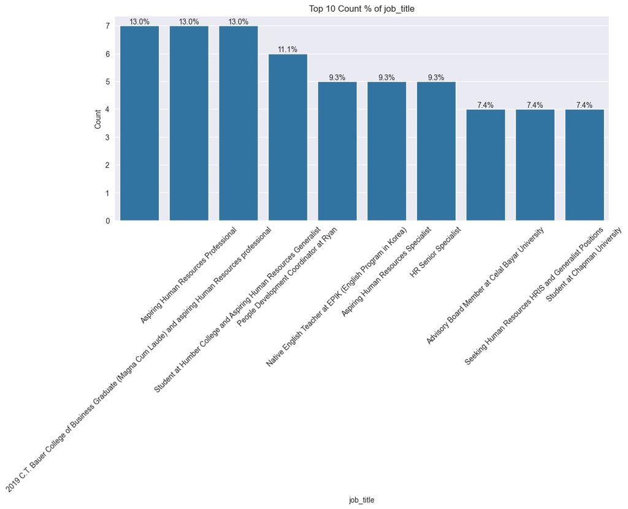

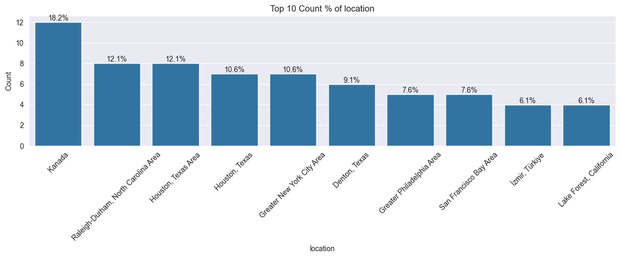

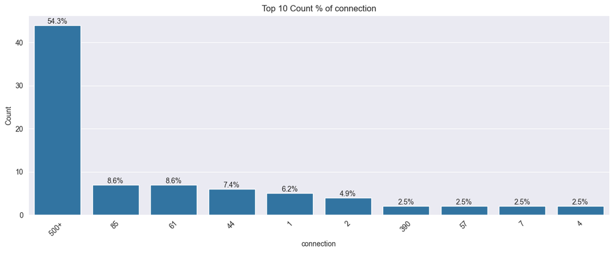

```python
"""
    plot_categorical_counts() : function to generate the count plots of discrete features
    @params : data - the pandas dataframe comprising the dataset, continuous_cols[] - an array holding the discrete features column names
    @return: None
"""

def plot_categorical_counts(data, categorical_cols):
    n = len(categorical_cols)
    plt.figure(figsize=(12, 5 * n))

    for i, col in enumerate(categorical_cols):
        plt.subplot(n, 1, i + 1)

        # Get top 10 most frequent categories
        top_categories = data[col].value_counts().nlargest(10).index
        filtered_data = data[data[col].isin(top_categories)]
        order = filtered_data[col].value_counts().index

        #ax = sns.countplot(data=filtered_data, x=col, order=order)
        ax = sns.countplot(data=filtered_data, x=col, order=order)

        total = len(filtered_data)
        for p in ax.patches:
            count = p.get_height()
            percent = f'{100 * count / total:.1f}%'
            ax.annotate(percent,
                        (p.get_x() + p.get_width() / 2., count),
                        ha='center', va='bottom', fontsize=10)

        plt.title(f'Top 10 Count % of {col}')
        plt.xticks(rotation=45)
        plt.xlabel(col)
        plt.ylabel('Count')

    plt.tight_layout()

plot_categorical_counts(data, ['job_title'])
plot_categorical_counts(data, ['location'])
plot_categorical_counts(data, ['connection'])
```

#### OBSERVATIONS

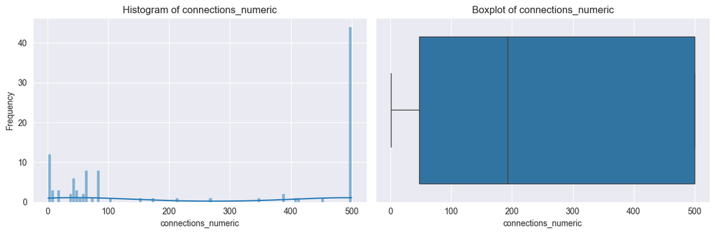

```python
'''
parse_connections() : function that converts the connection columnn from string to number -> "500+" becomes int(500)
@params : val - the value in the connection column at an instance
@return : the converted integer values
'''
def parse_connections(val):
    if pd.isna(val):
        return 0
    if isinstance(val, str) and "500" in val:
        return 500
    try:
        return int(val)
    except ValueError:
        return 0

# call the function and store in a new column - This will be later helpful during data preprocessing phase
data["connections_numeric"] = data["connection"].apply(parse_connections)


"""
    plot_hist_box() : function to generate the histogram and box plot for the given feature(s)
    @params : data - the pandas dataframe comprising the dataset, continuous_cols[] - an array holding the continuous features column names
    @return: None
"""
def plot_hist_box(data, continuous_cols):

    n = len(continuous_cols)
    plt.figure(figsize=(12, 4 * n))

    for i, col in enumerate(continuous_cols):
        # Histogram
        plt.subplot(n, 2, 2*i + 1)
        sns.histplot(data[col], bins=100, kde=True)
        plt.title(f'Histogram of {col}')
        plt.xlabel(col)
        plt.ylabel('Frequency')

        # Boxplot
        plt.subplot(n, 2, 2*i + 2)
        sns.boxplot(x=data[col])
        plt.title(f'Boxplot of {col}')
        plt.xlabel(col)

    plt.tight_layout()
    plt.show()

plot_hist_box(data, ['connections_numeric'])
```

#### OBSERVATIONS

- The distribution of the connected (post-conversion to numeric) does not follow a normal distribution.
- There are no outliers in the column, the median is around 200 and the max is 500, which is in line with its categorical version.
- The connections column, though technically a continuous, for this dataset atleast is somewhat discrete in nature.

### MULTIVARIATE ANALYSIS

```python
# create a test copy for multivariate analysis
df_test = data.copy()

# focus the analysis on only those records that are HR-related
df_test["has_hr_keyword"] = df_test["job_title"].str.lower().str.contains("human resources" or "hr")
df_test_hr = df_test[df_test['has_hr_keyword'] == True]

df_test_hr.head(10)
```

|  | id | job_title | location | connection | fit | connections_numeric | has_hr_keyword |
| --- | --- | --- | --- | --- | --- | --- | --- |
| 0 | 1 | 2019 C.T. Bauer College of Business Graduate (... | Houston, Texas | 85 | NaN | 85 | True |
| 2 | 3 | Aspiring Human Resources Professional | Raleigh-Durham, North Carolina Area | 44 | NaN | 44 | True |
| 5 | 6 | Aspiring Human Resources Specialist | Greater New York City Area | 1 | NaN | 1 | True |
| 6 | 7 | Student at Humber College and Aspiring Human R... | Kanada | 61 | NaN | 61 | True |
| 8 | 9 | Student at Humber College and Aspiring Human R... | Kanada | 61 | NaN | 61 | True |
| 9 | 10 | Seeking Human Resources HRIS and Generalist Po... | Greater Philadelphia Area | 500+ | NaN | 500 | True |
| 12 | 13 | Human Resources Coordinator at InterContinenta... | Atlanta, Georgia | 500+ | NaN | 500 | True |
| 13 | 14 | 2019 C.T. Bauer College of Business Graduate (... | Houston, Texas | 85 | NaN | 85 | True |
| 14 | 15 | 2019 C.T. Bauer College of Business Graduate (... | Houston, Texas | 85 | NaN | 85 | True |
| 16 | 17 | Aspiring Human Resources Professional | Raleigh-Durham, North Carolina Area | 44 | NaN | 44 | True |

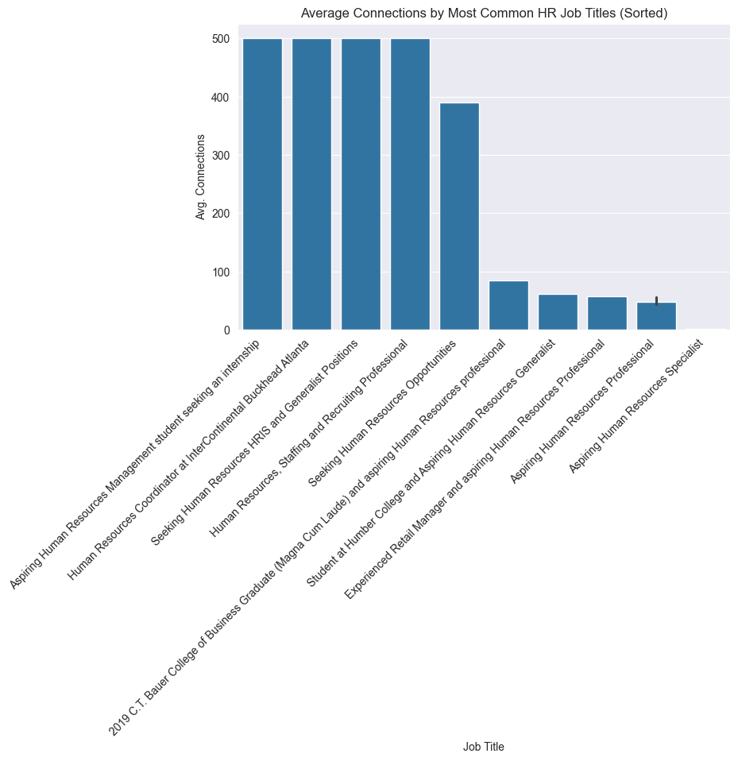

```python
# Identify top 10 HR job titles by frequency
top_titles = df_test_hr["job_title"].value_counts().head(10).index
df_top_titles = df_test_hr[df_test_hr["job_title"].isin(top_titles)]

# Compute average connections per job title
mean_connections = (
    df_top_titles.groupby("job_title")["connections_numeric"]
    .mean()
    .sort_values(ascending=False)
)

# Bar plot sorted by descending average connections
plt.figure(figsize=(8, 5))
sns.barplot(
    data=df_top_titles,
    x="job_title",
    y="connections_numeric",
    estimator=np.mean,
    order=mean_connections.index  # <- SORTED ORDER
)
plt.xticks(rotation=45, ha='right')
plt.title("Average Connections by Most Common HR Job Titles (Sorted)")
plt.ylabel("Avg. Connections")
plt.xlabel("Job Title")
plt.tight_layout()
plt.show()
```

#### OBSERVATIONS

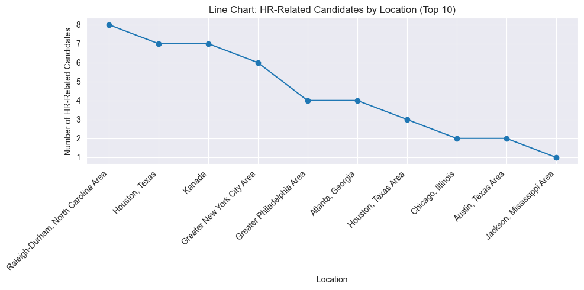

```python
# Count HR-related candidates by location (top 10 locations)
location_counts_hr = df_test_hr["location"].value_counts().head(10)

# Plot as a line chart
plt.figure(figsize=(10, 5))
plt.plot(location_counts_hr.index, location_counts_hr.values, marker='o', linestyle='-')
plt.title("Line Chart: HR-Related Candidates by Location (Top 10)")
plt.ylabel("Number of HR-Related Candidates")
plt.xlabel("Location")
plt.xticks(rotation=45, ha='right')
plt.grid(True)
plt.tight_layout()
plt.show()
```

#### OBSERVATIONS

- At an individual level, no of HR-related are mostly from Raleigh-Durham NC, but in totality they tend to be from Texas.
- Kanada which had the highest count overall, seems to have slightly lesser relevant HR candidates when viewed at a granular level.

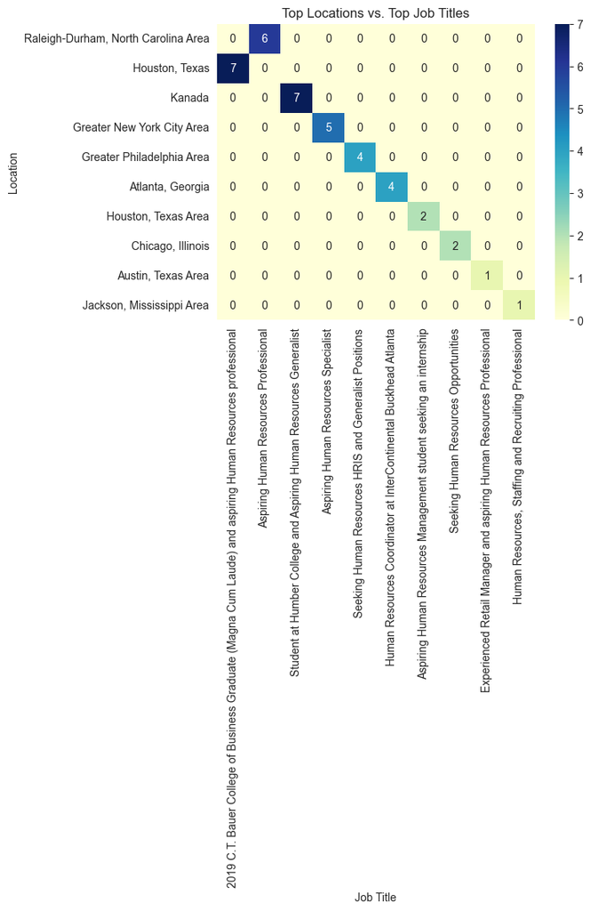

```python
# create a pivot table - which acts a heatmap for job titles by location - for the top 10 locations
pivot = pd.crosstab(df_test_hr["location"], df_test_hr["job_title"])
top_locations = df_test_hr["location"].value_counts().head(10).index
top_titles = df_test_hr["job_title"].value_counts().head(10).index
pivot = pivot.loc[top_locations, top_titles]

# visualize the pivot table as a heatmap
sns.heatmap(pivot, annot=True, fmt='d', cmap='YlGnBu')
plt.title("Top Locations vs. Top Job Titles")
plt.xlabel("Job Title")
plt.ylabel("Location")
plt.show()
```

#### OBSERVATIONS

- Further drilling granularly from the trends chart, it can validated the HR-specific candidates are mostly from Texas, NC and Canada.
- Additionally, the heatmap along with the trends chart, also corroborates the observation from the univariate analysis of the location feature.

## DATA PREPROCESSING

```python
# create a copy of the main dataset - we will use this for the ranking algorithm"
df = data.copy()
df.head(10)
```

|  | id | job_title | location | connection | fit | connections_numeric |
| --- | --- | --- | --- | --- | --- | --- |
| 0 | 1 | 2019 C.T. Bauer College of Business Graduate (... | Houston, Texas | 85 | NaN | 85 |
| 1 | 2 | Native English Teacher at EPIK (English Progra... | Kanada | 500+ | NaN | 500 |
| 2 | 3 | Aspiring Human Resources Professional | Raleigh-Durham, North Carolina Area | 44 | NaN | 44 |
| 3 | 4 | People Development Coordinator at Ryan | Denton, Texas | 500+ | NaN | 500 |
| 4 | 5 | Advisory Board Member at Celal Bayar University | İzmir, Türkiye | 500+ | NaN | 500 |
| 5 | 6 | Aspiring Human Resources Specialist | Greater New York City Area | 1 | NaN | 1 |
| 6 | 7 | Student at Humber College and Aspiring Human R... | Kanada | 61 | NaN | 61 |
| 7 | 8 | HR Senior Specialist | San Francisco Bay Area | 500+ | NaN | 500 |
| 8 | 9 | Student at Humber College and Aspiring Human R... | Kanada | 61 | NaN | 61 |
| 9 | 10 | Seeking Human Resources HRIS and Generalist Po... | Greater Philadelphia Area | 500+ | NaN | 500 |

```python
# 1. Define and load NLP models
nlp = spacy.load("en_core_web_sm", disable=["ner", "parser"])
stop_words = set(stopwords.words('english'))

# 2. Create abbreviations map
abbreviation_map = {
        "hr": "human resources",
        "mgr": "manager",
        "sr": "senior",
        "jr": "junior",
        "engg": "engineering"
    }

'''
normalize_text() : function that normalize the values of column in three steps
                    -> expands the abbrevations from the defined map
                    -> removed the stop words to make the values cleaner
                    -> lemmatizes the words so that it captures greater generalization during ranking
@params : text - the value in the defined column at an instance
@return : lemmatized tokens consolidated into a normalized string
'''

# 3. Normalize the features for the ranking process
def normalize_text(text):
    if pd.isna(text):
        return ""
    text = text.lower()
    text = re.sub(r'[' + string.punctuation + ']', ' ', text)
    words = text.split()
    # 1. Expand the abbreviations
    words = [abbreviation_map.get(w, w) for w in words]
    # 2. Remove stop words
    words = [w for w in words if w not in stop_words]
    # 4. Lemmatize the token for a generalized meaning
    doc = nlp(" ".join(words))
    lemmas = [token.lemma_ for token in doc]
    return " ".join(lemmas)


"""
preprocess_data() : function to apply text normalization and basic feature engineering to a dataframe.
                    -> Cleans and lemmatizes job_title
                    -> Standardizes location
                    -> performs sanity check on connections score as numeric
@params : input datafarme
@return:  dataframe with preprocessing applied
"""
def preprocess_data(df):

    df = df.copy()
    df["job_title_clean"] = df["job_title"].apply(normalize_text)
    df["location_clean"] = df["location"].fillna("").str.lower().str.strip()

    # Optional: numeric conversion if not already done
    if "connections_numeric" not in df.columns:
        df["connections_numeric"] = df["connection"].replace("500+", 500).astype(int)

    return df

df_normalized = preprocess_data(df)
df_normalized.head(10)
```

|  | id | job_title | location | connection | fit | connections_numeric | job_title_clean | location_clean |
| --- | --- | --- | --- | --- | --- | --- | --- | --- |
| 0 | 1 | 2019 C.T. Bauer College of Business Graduate (... | Houston, Texas | 85 | NaN | 85 | 2019 c bauer college business graduate magna c... | houston, texas |
| 1 | 2 | Native English Teacher at EPIK (English Progra... | Kanada | 500+ | NaN | 500 | native english teacher epik english program korea | kanada |
| 2 | 3 | Aspiring Human Resources Professional | Raleigh-Durham, North Carolina Area | 44 | NaN | 44 | aspire human resource professional | raleigh-durham, north carolina area |
| 3 | 4 | People Development Coordinator at Ryan | Denton, Texas | 500+ | NaN | 500 | people development coordinator ryan | denton, texas |
| 4 | 5 | Advisory Board Member at Celal Bayar University | İzmir, Türkiye | 500+ | NaN | 500 | advisory board member celal bayar university | i̇zmir, türkiye |
| 5 | 6 | Aspiring Human Resources Specialist | Greater New York City Area | 1 | NaN | 1 | aspire human resource specialist | greater new york city area |
| 6 | 7 | Student at Humber College and Aspiring Human R... | Kanada | 61 | NaN | 61 | student humber college aspire human resource g... | kanada |
| 7 | 8 | HR Senior Specialist | San Francisco Bay Area | 500+ | NaN | 500 | human resource senior specialist | san francisco bay area |
| 8 | 9 | Student at Humber College and Aspiring Human R... | Kanada | 61 | NaN | 61 | student humber college aspire human resource g... | kanada |
| 9 | 10 | Seeking Human Resources HRIS and Generalist Po... | Greater Philadelphia Area | 500+ | NaN | 500 | seek human resource hris generalist position | greater philadelphia area |

## FEATURE ENGINEERING

### COMPUTE FIT WITH COSINE SIMILARITY

```python
from sklearn.feature_extraction.text import TfidfVectorizer
from sklearn.metrics.pairwise import cosine_similarity

"""
compute_cosine_fit() : function to compute cosine similarity between job titles and target phrases to calculate a fit score.
@params : -> df - input dataFrame with a 'job_title_clean' column
          -> target_phrases - list of target role phrases (e.g., ["aspiring human resources"])
          -> w_title, w_connections, w_location: preset weights for each component of the fit
@returns : output dataframe with calculated fit, computed job_vectors (i.e. feature vectors) and target vectors
"""
def compute_cosine_fit(df, target_phrases, w_title=1.0, w_connections=0.0, w_location=0.0):

    df = df.copy()

    # Normalize target phrases
    target_phrases_norm = [normalize_text(p) for p in target_phrases]

    # Combine job titles + targets for vectorization
    corpus = df["job_title_clean"].tolist() + target_phrases_norm

    # Vectorize with TF-IDF
    vectorizer = TfidfVectorizer()
    tfidf_matrix = vectorizer.fit_transform(corpus)

    # Separate vectors
    job_vectors = tfidf_matrix[:len(df)]
    target_vectors = tfidf_matrix[len(df):]

    # Cosine similarity between jobs and targets
    similarities = cosine_similarity(job_vectors, target_vectors)
    df["title_similarity"] = similarities.mean(axis=1)

    # Normalize connection scores
    df["connections_score"] = df["connections_numeric"] / df["connections_numeric"].max()

    # Dummy location score
    df["location_score"] = 0.0

    # Weighted fit score
    df["fit"] = (
        w_title * df["title_similarity"] +
        w_connections * df["connections_score"] +
        w_location * df["location_score"]
    )

    return df, job_vectors, target_vectors  # return job_vectors, target_vectors to be reused for re-ranking step and KL computation

target_phrases = ["aspiring human resources", "seeking human resources"]
df_normalized, job_vectors, target_vectors = compute_cosine_fit(df_normalized, target_phrases)

df_normalized[["id", "job_title", "title_similarity", "connections_score", "location_score", "fit"]].sort_values("fit", ascending=False)
```

|  | id | job_title | title_similarity | connections_score | location_score | fit |
| --- | --- | --- | --- | --- | --- | --- |
| 72 | 73 | Aspiring Human Resources Manager, seeking inte... | 0.577697 | 0.014 | 0.0 | 0.577697 |
| 2 | 3 | Aspiring Human Resources Professional | 0.523032 | 0.088 | 0.0 | 0.523032 |
| 16 | 17 | Aspiring Human Resources Professional | 0.523032 | 0.088 | 0.0 | 0.523032 |
| 32 | 33 | Aspiring Human Resources Professional | 0.523032 | 0.088 | 0.0 | 0.523032 |
| 57 | 58 | Aspiring Human Resources Professional | 0.523032 | 0.088 | 0.0 | 0.523032 |
| ... | ... | ... | ... | ... | ... | ... |
| 90 | 91 | Lead Official at Western Illinois University | 0.000000 | 0.078 | 0.0 | 0.000000 |
| 97 | 98 | Student | 0.000000 | 0.008 | 0.0 | 0.000000 |
| 101 | 102 | Business Intelligence and Analytics at Travelers | 0.000000 | 0.098 | 0.0 | 0.000000 |
| 102 | 103 | Always set them up for Success | 0.000000 | 1.000 | 0.0 | 0.000000 |
| 103 | 104 | Director Of Administration at Excellence Logging | 0.000000 | 1.000 | 0.0 | 0.000000 |

104 rows × 6 columns

### COMPUTE FIT KULLBACK-LIEBLER (KL) DIVERGENCE

```python
from sklearn.preprocessing import normalize
from scipy.special import rel_entr
import numpy as np

"""
compute_kl_fit() : function to compute KL-divergence-based fit score for job titles compared to target vectors.

@params : df - input dataFrame to which the KL-based fit score will be added,
          job_vectors - TF-IDF vectors of job titles
          target_vectors: TF-IDF vectors of target phrases

@returns : output dataframe with new calculate field 'fit_alt' (KL-based similarity score)
"""
def compute_kl_fit(df, job_vectors, target_vectors):

    df = df.copy()

    # 1. Convert sparse vectors to dense arrays
    job_vectors_array = job_vectors.toarray()
    target_vectors_array = target_vectors.toarray()

    # 2. L1 normalize to create valid probability distributions
    job_probs = normalize(job_vectors_array, norm='l1', axis=1)
    target_probs = normalize(target_vectors_array, norm='l1', axis=1)

    # 3. Add smoothing to avoid log(0)
    epsilon = 1e-10
    job_probs += epsilon
    target_probs += epsilon

    # 4. Compute average target distribution
    avg_target_prob = np.mean(target_probs, axis=0)

    # 5. KL divergence per job: KL(P || Q)
    kl_divs = [np.sum(rel_entr(p, avg_target_prob)) for p in job_probs]

    # 6. Inverse & normalize to convert to similarity
    kl_similarity = 1 / (1 + np.array(kl_divs))
    kl_similarity_norm = (kl_similarity - kl_similarity.min()) / (kl_similarity.max() - kl_similarity.min())

    # 7. Assign to dataframe
    df["fit_alt"] = kl_similarity_norm

    return df

df_normalized = compute_kl_fit(df_normalized, job_vectors, target_vectors)
df_normalized[["id", "job_title", "title_similarity", "connections_score", "fit", "fit_alt"]].sort_values("fit_alt", ascending=False)
```

|  | id | job_title | title_similarity | connections_score | fit | fit_alt |
| --- | --- | --- | --- | --- | --- | --- |
| 2 | 3 | Aspiring Human Resources Professional | 0.523032 | 0.088 | 0.523032 | 1.000000 |
| 32 | 33 | Aspiring Human Resources Professional | 0.523032 | 0.088 | 0.523032 | 1.000000 |
| 16 | 17 | Aspiring Human Resources Professional | 0.523032 | 0.088 | 0.523032 | 1.000000 |
| 20 | 21 | Aspiring Human Resources Professional | 0.523032 | 0.088 | 0.523032 | 1.000000 |
| 57 | 58 | Aspiring Human Resources Professional | 0.523032 | 0.088 | 0.523032 | 1.000000 |
| ... | ... | ... | ... | ... | ... | ... |
| 10 | 11 | Student at Chapman University | 0.000000 | 0.004 | 0.000000 | 0.025969 |
| 62 | 63 | Student at Chapman University | 0.000000 | 0.004 | 0.000000 | 0.025969 |
| 53 | 54 | Student at Chapman University | 0.000000 | 0.004 | 0.000000 | 0.025969 |
| 40 | 41 | Student at Chapman University | 0.000000 | 0.004 | 0.000000 | 0.025969 |
| 97 | 98 | Student | 0.000000 | 0.008 | 0.000000 | 0.000000 |

104 rows × 6 columns

### PERFORMANCE EVALUATION

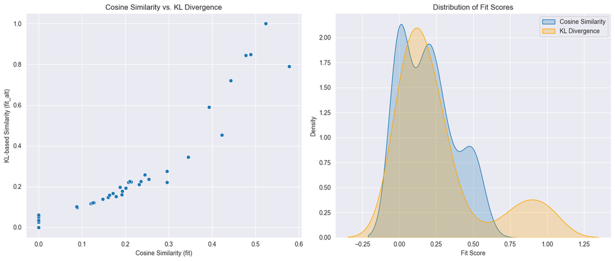

```python
fig, axes = plt.subplots(1, 2, figsize=(14, 6))

# Scatter plot: Cosine vs KL
sns.scatterplot(data=df_normalized, x="fit", y="fit_alt", ax=axes[0])
axes[0].set_title("Cosine Similarity vs. KL Divergence")
axes[0].set_xlabel("Cosine Similarity (fit)")
axes[0].set_ylabel("KL-based Similarity (fit_alt)")
axes[0].grid(True)

# KDE plot: Score Distributions
sns.kdeplot(df_normalized["fit"], label="Cosine Similarity", fill=True, ax=axes[1])
sns.kdeplot(df_normalized["fit_alt"], label="KL Divergence", fill=True, ax=axes[1], color="orange")
axes[1].set_title("Distribution of Fit Scores")
axes[1].set_xlabel("Fit Score")
axes[1].set_ylabel("Density")
axes[1].legend()

plt.tight_layout()
plt.show()
```

#### OBSERVATIONS

##### SCATTER PLOT

- There's a positive, nonlinear correlation b/w the two - as cosine similarity increases, KL similarity also increases.
- Most data points are clustered toward the lower-left, i.e. many candidates have low similarity by both measures, likley the ones that are not HR-specific candidates.
- A few points in the top-right quadrant show agreement b/w the two approaches for the high-fit candidates.

##### KDE PLOT

- Cosine similarity (fit) has a sharper peak around 0.1–0.2 and drops off quickly.
- KL Divergence similarity (fit_alt) has a wider, flatter distribution with a longer tail toward higher values.

##### INFERENCES AND SUGGESTED APPROACH

- Both metrics generally agree on poor and strong matches, but diverge in the mid-range.
- KL divergence tends to better distinguish the fit in high-similarity candidates, and captures behavior at greater granularity.
- On the other hand, the Cosine similarity helps validate the matches based on token alignment as in the keyword match.
- Suggest Approach - Use an integrated approach, use KL as primary signal and the Cosine similarity as second signal.

## RANKING MODEL

### BASELINE MODEL TESTING

```python
from sklearn.preprocessing import MinMaxScaler

"""
integrate_fit_scores() : function to normalize and blend cosine and KL-based scores into a single integrated fit score.

@params :
    - df: input dataFrame containing 'fit' (cosine) and 'fit_alt' (KL)
    - w_kl: weight for KL divergence
    - w_cosine: weight for cosine similarity

@return: df - output dataframe with calculated fields 'fit_norm', 'fit_alt_norm', 'fit_integrated'

"""

def integrate_fit_scores(df, w_kl=0.8, w_cosine=0.2):

    df = df.copy()

    scaler = MinMaxScaler()
    df["fit_norm"] = scaler.fit_transform(df[["fit"]])
    df["fit_alt_norm"] = scaler.fit_transform(df[["fit_alt"]])

    df["fit_integrated"] = (
        w_kl * df["fit_alt_norm"] +
        w_cosine * df["fit_norm"]
    )

    return df

df_normalized = integrate_fit_scores(df_normalized, w_kl=0.8, w_cosine=0.2)

# Sort candidates by final fit
df_normalized[["id", "job_title", "title_similarity", "connections_score", "fit", "fit_alt", "fit_norm", "fit_alt_norm", 'fit_integrated']].\
sort_values("fit_integrated", ascending=False)
```

|  | id | job_title | title_similarity | connections_score | fit | fit_alt | fit_norm | fit_alt_norm | fit_integrated |
| --- | --- | --- | --- | --- | --- | --- | --- | --- | --- |
| 2 | 3 | Aspiring Human Resources Professional | 0.523032 | 0.088 | 0.523032 | 1.000000 | 0.905376 | 1.000000 | 0.981075 |
| 32 | 33 | Aspiring Human Resources Professional | 0.523032 | 0.088 | 0.523032 | 1.000000 | 0.905376 | 1.000000 | 0.981075 |
| 16 | 17 | Aspiring Human Resources Professional | 0.523032 | 0.088 | 0.523032 | 1.000000 | 0.905376 | 1.000000 | 0.981075 |
| 20 | 21 | Aspiring Human Resources Professional | 0.523032 | 0.088 | 0.523032 | 1.000000 | 0.905376 | 1.000000 | 0.981075 |
| 57 | 58 | Aspiring Human Resources Professional | 0.523032 | 0.088 | 0.523032 | 1.000000 | 0.905376 | 1.000000 | 0.981075 |
| ... | ... | ... | ... | ... | ... | ... | ... | ... | ... |
| 10 | 11 | Student at Chapman University | 0.000000 | 0.004 | 0.000000 | 0.025969 | 0.000000 | 0.025969 | 0.020776 |
| 62 | 63 | Student at Chapman University | 0.000000 | 0.004 | 0.000000 | 0.025969 | 0.000000 | 0.025969 | 0.020776 |
| 53 | 54 | Student at Chapman University | 0.000000 | 0.004 | 0.000000 | 0.025969 | 0.000000 | 0.025969 | 0.020776 |
| 40 | 41 | Student at Chapman University | 0.000000 | 0.004 | 0.000000 | 0.025969 | 0.000000 | 0.025969 | 0.020776 |
| 97 | 98 | Student | 0.000000 | 0.008 | 0.000000 | 0.000000 | 0.000000 | 0.000000 | 0.000000 |

104 rows × 9 columns

```python
# 1. Top-ranked candidates
top_candidates = df_normalized.sort_values("fit_integrated", ascending=False).head(10)
print(" \n Top 10 Ranked Candidates: \n")
top_candidates[["id", "job_title", "title_similarity", "connections_numeric", "fit_integrated"]]
```

```
 Top 10 Ranked Candidates:
```

|  | id | job_title | title_similarity | connections_numeric | fit_integrated |
| --- | --- | --- | --- | --- | --- |
| 2 | 3 | Aspiring Human Resources Professional | 0.523032 | 44 | 0.981075 |
| 32 | 33 | Aspiring Human Resources Professional | 0.523032 | 44 | 0.981075 |
| 16 | 17 | Aspiring Human Resources Professional | 0.523032 | 44 | 0.981075 |
| 20 | 21 | Aspiring Human Resources Professional | 0.523032 | 44 | 0.981075 |
| 57 | 58 | Aspiring Human Resources Professional | 0.523032 | 44 | 0.981075 |
| 96 | 97 | Aspiring Human Resources Professional | 0.523032 | 71 | 0.981075 |
| 45 | 46 | Aspiring Human Resources Professional | 0.523032 | 44 | 0.981075 |
| 98 | 99 | Seeking Human Resources Position | 0.488586 | 48 | 0.847390 |
| 23 | 24 | Aspiring Human Resources Specialist | 0.477482 | 1 | 0.840630 |
| 5 | 6 | Aspiring Human Resources Specialist | 0.477482 | 1 | 0.840630 |

```python
# 2. Bottom-ranked candidates
bottom_candidates = df_normalized.sort_values("fit_integrated", ascending=True).head(10)
print("\n Bottom 10 Ranked Candidates: \n")
bottom_candidates[["id", "job_title", "title_similarity", "connections_numeric", "fit_integrated"]]
```

```
 Bottom 10 Ranked Candidates:
```

|  | id | job_title | title_similarity | connections_numeric | fit_integrated |
| --- | --- | --- | --- | --- | --- |
| 97 | 98 | Student | 0.0 | 4 | 0.000000 |
| 10 | 11 | Student at Chapman University | 0.0 | 2 | 0.020776 |
| 53 | 54 | Student at Chapman University | 0.0 | 2 | 0.020776 |
| 62 | 63 | Student at Chapman University | 0.0 | 2 | 0.020776 |
| 40 | 41 | Student at Chapman University | 0.0 | 2 | 0.020776 |
| 102 | 103 | Always set them up for Success | 0.0 | 500 | 0.021018 |
| 94 | 95 | Student at Westfield State University | 0.0 | 57 | 0.026191 |
| 101 | 102 | Business Intelligence and Analytics at Travelers | 0.0 | 49 | 0.026533 |
| 103 | 104 | Director Of Administration at Excellence Logging | 0.0 | 500 | 0.026817 |
| 58 | 59 | People Development Coordinator at Ryan | 0.0 | 500 | 0.026828 |

```python
# 3. Fit Score Summary stats
print("\n Fit Score Summary: \n")
df_normalized["fit_integrated"].describe()
```

```
 Fit Score Summary:
```

```
count    104.000000
mean       0.276440
std        0.292892
min        0.000000
25%        0.035253
50%        0.195237
75%        0.322861
max        0.981075
Name: fit_integrated, dtype: float64
```

```python
# 3. Summary stats
print("\n Title Similarity Summary: \n")
df_normalized["title_similarity"].describe()
```

```
 Title Similarity Summary:
```

```
count    104.000000
mean       0.190810
std        0.177908
min        0.000000
25%        0.000000
50%        0.189481
75%        0.295653
max        0.577697
Name: title_similarity, dtype: float64
```

#### OBSERVATIONS

- The top 10 candidates, all of them, have the target keywords as defined the client which indicates that keyword matching is important.
- Conversely, the bottom candidates, none of them have the target keywords which indicates they are not relevant for this HR job.
- Another key observation is that some bottom candidates have more LinkedIn connections that top candidates - so, connections is not much deterministic of the fit.

### RE-RANK USING A STARRED CANDIDATE

```python
import random

"""
re_rank_with_single_starred() : Re-ranks candidates by selecting one random candidate from top-N as a starred candidate.
@params :
    -> df - input dataFrame with 'fit_integrated' scores
    -> job_vectors - TF-IDF vectors of job titles
    -> top_n - Number of top candidates to sample from
    -> w_fit - Weight for original fit score
    -> w_starred - Weight for similarity to starred candidate

@return : df_re_ranked: output dataframe reranked based on updated fit score
"""

def re_rank_with_single_starred(df, job_vectors, top_n=10, w_fit=0.5, w_starred=0.5):

    df = df.copy()

    # Step 1–2: Randomly select one candidate from top-N
    df_top_n = df.sort_values("fit_integrated", ascending=False).head(top_n)
    random_selection = random.choice(df_top_n["id"].tolist())
    print(f"\n Randomly selected candidate ID (starred): {random_selection} \n")

    # Step 3: Mark the starred candidate
    df["is_starred"] = df["id"] == random_selection

    # Step 4: Get starred candidate vector
    starred_idx = df[df["id"] == random_selection].index[0]
    starred_vector = job_vectors[starred_idx]

    # Step 5: Cosine similarity to starred candidate
    df["similarity_to_starred"] = cosine_similarity(job_vectors, starred_vector).flatten()

    # Step 6: Combine fit scores
    df["fit_updated"] = (
        w_fit * df["fit_integrated"] +
        w_starred * df["similarity_to_starred"]
    )

    # Step 7: Re-rank
    df_re_ranked = df.sort_values("fit_updated", ascending=False)

    return df_re_ranked

df_re_ranked = re_rank_with_single_starred(df_normalized, job_vectors)
df_re_ranked[["id", "job_title", "fit_updated", "fit_integrated", "similarity_to_starred", "is_starred"]].head(10)
```

```
 Randomly selected candidate ID (starred): 21
```

|  | id | job_title | fit_updated | fit_integrated | similarity_to_starred | is_starred |
| --- | --- | --- | --- | --- | --- | --- |
| 2 | 3 | Aspiring Human Resources Professional | 0.990538 | 0.981075 | 1.000000 | False |
| 32 | 33 | Aspiring Human Resources Professional | 0.990538 | 0.981075 | 1.000000 | False |
| 16 | 17 | Aspiring Human Resources Professional | 0.990538 | 0.981075 | 1.000000 | False |
| 20 | 21 | Aspiring Human Resources Professional | 0.990538 | 0.981075 | 1.000000 | True |
| 57 | 58 | Aspiring Human Resources Professional | 0.990538 | 0.981075 | 1.000000 | False |
| 96 | 97 | Aspiring Human Resources Professional | 0.990538 | 0.981075 | 1.000000 | False |
| 45 | 46 | Aspiring Human Resources Professional | 0.990538 | 0.981075 | 1.000000 | False |
| 73 | 74 | Human Resources Professional | 0.726907 | 0.607596 | 0.846219 | False |
| 23 | 24 | Aspiring Human Resources Specialist | 0.673589 | 0.840630 | 0.506548 | False |
| 5 | 6 | Aspiring Human Resources Specialist | 0.673589 | 0.840630 | 0.506548 | False |

### DETERMINE THE THRESHOLD HEURISTICALLY

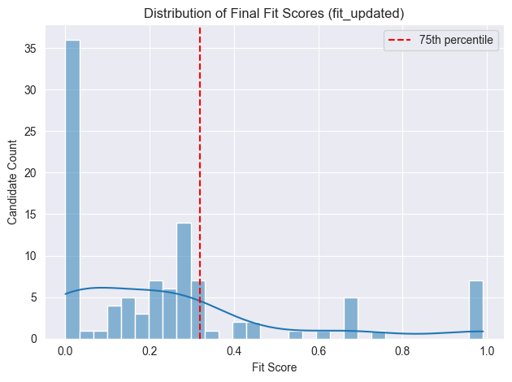

```python
# Visualize distribution
sns.histplot(df_re_ranked["fit_updated"], bins=30, kde=True)
plt.axvline(df_re_ranked["fit_updated"].quantile(0.75), color="red", linestyle="--", label="75th percentile")
plt.title("Distribution of Final Fit Scores (fit_updated)")
plt.xlabel("Fit Score")
plt.ylabel("Candidate Count")
plt.legend()
plt.tight_layout()
plt.show()
```

#### OBSERVATIONS

```python
"""
get_potential_candidates() : function to filter out candidates above a specified quantile threshold based on fit score.

@params :
    -> df - input dataframe with fit scores
    -> score_col - Column name containing the final fit score
    -> quantile - Quantile to use as threshold (e.g., 0.75 for top 25%)

@return : potential_candidates - output dataframe filteredt with only top candidates
"""
def get_potential_candidates(df, score_col="fit_updated", quantile=0.75):
    df = df.copy()
    cutoff = df[score_col].quantile(quantile)
    selected_candidates = df[df[score_col] >= cutoff]
    print(f"\n Selected {len(selected_candidates)} candidates above threshold of {cutoff:.3f} (Quantile = {quantile})\n")
    return selected_candidates

potential_candidates = get_potential_candidates(df_re_ranked)
potential_candidates[["id", "job_title", "similarity_to_starred", "fit_integrated", "fit_updated"]]
```

```
 Selected 27 candidates above threshold of 0.318 (Quantile = 0.75)
```

|  | id | job_title | similarity_to_starred | fit_integrated | fit_updated |
| --- | --- | --- | --- | --- | --- |
| 2 | 3 | Aspiring Human Resources Professional | 1.000000 | 0.981075 | 0.990538 |
| 32 | 33 | Aspiring Human Resources Professional | 1.000000 | 0.981075 | 0.990538 |
| 16 | 17 | Aspiring Human Resources Professional | 1.000000 | 0.981075 | 0.990538 |
| 20 | 21 | Aspiring Human Resources Professional | 1.000000 | 0.981075 | 0.990538 |
| 57 | 58 | Aspiring Human Resources Professional | 1.000000 | 0.981075 | 0.990538 |
| 96 | 97 | Aspiring Human Resources Professional | 1.000000 | 0.981075 | 0.990538 |
| 45 | 46 | Aspiring Human Resources Professional | 1.000000 | 0.981075 | 0.990538 |
| 73 | 74 | Human Resources Professional | 0.846219 | 0.607596 | 0.726907 |
| 23 | 24 | Aspiring Human Resources Specialist | 0.506548 | 0.840630 | 0.673589 |
| 5 | 6 | Aspiring Human Resources Specialist | 0.506548 | 0.840630 | 0.673589 |
| 48 | 49 | Aspiring Human Resources Specialist | 0.506548 | 0.840630 | 0.673589 |
| 59 | 60 | Aspiring Human Resources Specialist | 0.506548 | 0.840630 | 0.673589 |
| 35 | 36 | Aspiring Human Resources Specialist | 0.506548 | 0.840630 | 0.673589 |
| 72 | 73 | Aspiring Human Resources Manager, seeking inte... | 0.413143 | 0.831971 | 0.622557 |
| 98 | 99 | Seeking Human Resources Position | 0.209564 | 0.847390 | 0.528477 |
| 27 | 28 | Seeking Human Resources Opportunities | 0.189872 | 0.729166 | 0.459519 |
| 29 | 30 | Seeking Human Resources Opportunities | 0.189872 | 0.729166 | 0.459519 |
| 28 | 29 | Aspiring Human Resources Management student se... | 0.285152 | 0.509253 | 0.397202 |
| 26 | 27 | Aspiring Human Resources Management student se... | 0.285152 | 0.509253 | 0.397202 |
| 65 | 66 | Experienced Retail Manager and aspiring Human ... | 0.451040 | 0.261364 | 0.356202 |
| 36 | 37 | Student at Humber College and Aspiring Human R... | 0.313650 | 0.322861 | 0.318256 |
| 6 | 7 | Student at Humber College and Aspiring Human R... | 0.313650 | 0.322861 | 0.318256 |
| 38 | 39 | Student at Humber College and Aspiring Human R... | 0.313650 | 0.322861 | 0.318256 |
| 24 | 25 | Student at Humber College and Aspiring Human R... | 0.313650 | 0.322861 | 0.318256 |
| 49 | 50 | Student at Humber College and Aspiring Human R... | 0.313650 | 0.322861 | 0.318256 |
| 51 | 52 | Student at Humber College and Aspiring Human R... | 0.313650 | 0.322861 | 0.318256 |
| 8 | 9 | Student at Humber College and Aspiring Human R... | 0.313650 | 0.322861 | 0.318256 |

### MULTIPLE FEEDBACK SIMULATION

```python
"""
re_rank_with_multiple_feedback_simulation() : function to simulate re-ranking based on multiple starred candidates from top-K fit scores.

@params :
    -> df - DataFrame with 'fit_integrated'
    -> job_vectors - TF-IDF vectors for job titles
    -> N - Number of candidates to randomly star
    -> top_k - Number of top candidates to consider for random selection
    -> w_integrated - Weight for original integrated fit
    -> w_starred - Weight for similarity to starred candidates

@return : df_re_ranked_mfs - Re-ranked DataFrame after feedback-based update

"""

def re_rank_with_multiple_feedback_simulation(df, job_vectors, N=3, top_k=15, w_integrated=0.5, w_starred=0.5):

    df = df.copy()

    # Step 1: Randomly select N starred candidates from top-K
    df_top_n = df.sort_values("fit_integrated", ascending=False).head(top_k)
    starred_ids = random.sample(df_top_n["id"].tolist(), N)
    print(f"\n Randomly starred candidate IDs: {starred_ids} \n")

    # Step 2: Mark starred candidates
    df["is_starred"] = df["id"].isin(starred_ids)

    # Step 3: Get TF-IDF vectors for starred candidates
    starred_indices = df[df["is_starred"]].index
    starred_vectors = job_vectors[starred_indices]

    # Step 4–5: Compute average similarity to all starred candidates
    similarity_matrix = cosine_similarity(job_vectors, starred_vectors)
    df["similarity_to_starred"] = similarity_matrix.mean(axis=1)

    # Step 6: Recompute final score
    df["fit_updated"] = (
        w_integrated * df["fit_integrated"] +
        w_starred * df["similarity_to_starred"]
    )

    # Step 7: Sort by updated fit score
    df_re_ranked_mfs = df.sort_values("fit_updated", ascending=False)

    return df_re_ranked_mfs

df_re_ranked_mfs = re_rank_with_multiple_feedback_simulation(df_normalized, job_vectors)
print("\n Top 15 Candidates After Feedback-Based Re-Ranking: \n")
df_re_ranked_mfs[["id", "job_title","similarity_to_starred", "is_starred", "fit_updated", "fit_integrated"]].head(15)
```

```
 Randomly starred candidate IDs: [73, 99, 3]


 Top 15 Candidates After Feedback-Based Re-Ranking:
```

|  | id | job_title | similarity_to_starred | is_starred | fit_updated | fit_integrated |
| --- | --- | --- | --- | --- | --- | --- |
| 2 | 3 | Aspiring Human Resources Professional | 0.540903 | True | 0.760989 | 0.981075 |
| 32 | 33 | Aspiring Human Resources Professional | 0.540903 | False | 0.760989 | 0.981075 |
| 16 | 17 | Aspiring Human Resources Professional | 0.540903 | False | 0.760989 | 0.981075 |
| 20 | 21 | Aspiring Human Resources Professional | 0.540903 | False | 0.760989 | 0.981075 |
| 57 | 58 | Aspiring Human Resources Professional | 0.540903 | False | 0.760989 | 0.981075 |
| 96 | 97 | Aspiring Human Resources Professional | 0.540903 | False | 0.760989 | 0.981075 |
| 45 | 46 | Aspiring Human Resources Professional | 0.540903 | False | 0.760989 | 0.981075 |
| 72 | 73 | Aspiring Human Resources Manager, seeking inte... | 0.610392 | True | 0.721182 | 0.831971 |
| 98 | 99 | Seeking Human Resources Position | 0.542532 | True | 0.694961 | 0.847390 |
| 23 | 24 | Aspiring Human Resources Specialist | 0.358342 | False | 0.599486 | 0.840630 |
| 59 | 60 | Aspiring Human Resources Specialist | 0.358342 | False | 0.599486 | 0.840630 |
| 48 | 49 | Aspiring Human Resources Specialist | 0.358342 | False | 0.599486 | 0.840630 |
| 35 | 36 | Aspiring Human Resources Specialist | 0.358342 | False | 0.599486 | 0.840630 |
| 5 | 6 | Aspiring Human Resources Specialist | 0.358342 | False | 0.599486 | 0.840630 |
| 73 | 74 | Human Resources Professional | 0.471414 | False | 0.539505 | 0.607596 |

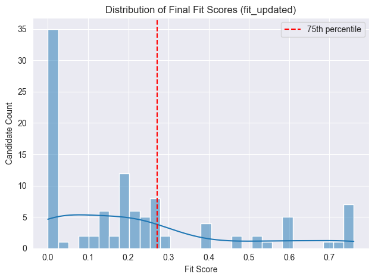

```python
# Visualize distribution
sns.histplot(df_re_ranked_mfs["fit_updated"], bins=30, kde=True)
plt.axvline(df_re_ranked_mfs["fit_updated"].quantile(0.75), color="red", linestyle="--", label="75th percentile")
plt.title("Distribution of Final Fit Scores (fit_updated)")
plt.xlabel("Fit Score")
plt.ylabel("Candidate Count")
plt.legend()
plt.tight_layout()
plt.show()
```

```python
# filter out the potential candidates based on the multiple feedback simulation
potential_candidates_mfs = get_potential_candidates(df_re_ranked_mfs)
potential_candidates_mfs[["id", "job_title", "similarity_to_starred", "fit_integrated", "fit_updated"]]
```

```
 Selected 32 candidates above threshold of 0.272 (Quantile = 0.75)
```

|  | id | job_title | similarity_to_starred | fit_integrated | fit_updated |
| --- | --- | --- | --- | --- | --- |
| 2 | 3 | Aspiring Human Resources Professional | 0.540903 | 0.981075 | 0.760989 |
| 32 | 33 | Aspiring Human Resources Professional | 0.540903 | 0.981075 | 0.760989 |
| 16 | 17 | Aspiring Human Resources Professional | 0.540903 | 0.981075 | 0.760989 |
| 20 | 21 | Aspiring Human Resources Professional | 0.540903 | 0.981075 | 0.760989 |
| 57 | 58 | Aspiring Human Resources Professional | 0.540903 | 0.981075 | 0.760989 |
| 96 | 97 | Aspiring Human Resources Professional | 0.540903 | 0.981075 | 0.760989 |
| 45 | 46 | Aspiring Human Resources Professional | 0.540903 | 0.981075 | 0.760989 |
| 72 | 73 | Aspiring Human Resources Manager, seeking inte... | 0.610392 | 0.831971 | 0.721182 |
| 98 | 99 | Seeking Human Resources Position | 0.542532 | 0.847390 | 0.694961 |
| 23 | 24 | Aspiring Human Resources Specialist | 0.358342 | 0.840630 | 0.599486 |
| 59 | 60 | Aspiring Human Resources Specialist | 0.358342 | 0.840630 | 0.599486 |
| 48 | 49 | Aspiring Human Resources Specialist | 0.358342 | 0.840630 | 0.599486 |
| 35 | 36 | Aspiring Human Resources Specialist | 0.358342 | 0.840630 | 0.599486 |
| 5 | 6 | Aspiring Human Resources Specialist | 0.358342 | 0.840630 | 0.599486 |
| 73 | 74 | Human Resources Professional | 0.471414 | 0.607596 | 0.539505 |
| 27 | 28 | Seeking Human Resources Opportunities | 0.335771 | 0.729166 | 0.532469 |
| 29 | 30 | Seeking Human Resources Opportunities | 0.335771 | 0.729166 | 0.532469 |
| 28 | 29 | Aspiring Human Resources Management student se... | 0.424367 | 0.509253 | 0.466810 |
| 26 | 27 | Aspiring Human Resources Management student se... | 0.424367 | 0.509253 | 0.466810 |
| 39 | 40 | Seeking Human Resources HRIS and Generalist Po... | 0.382606 | 0.395329 | 0.388968 |
| 9 | 10 | Seeking Human Resources HRIS and Generalist Po... | 0.382606 | 0.395329 | 0.388968 |
| 52 | 53 | Seeking Human Resources HRIS and Generalist Po... | 0.382606 | 0.395329 | 0.388968 |
| 61 | 62 | Seeking Human Resources HRIS and Generalist Po... | 0.382606 | 0.395329 | 0.388968 |
| 99 | 100 | Aspiring Human Resources Manager \| Graduating ... | 0.317251 | 0.278693 | 0.297972 |
| 65 | 66 | Experienced Retail Manager and aspiring Human ... | 0.308826 | 0.261364 | 0.285095 |
| 38 | 39 | Student at Humber College and Aspiring Human R... | 0.221882 | 0.322861 | 0.272372 |
| 51 | 52 | Student at Humber College and Aspiring Human R... | 0.221882 | 0.322861 | 0.272372 |
| 49 | 50 | Student at Humber College and Aspiring Human R... | 0.221882 | 0.322861 | 0.272372 |
| 36 | 37 | Student at Humber College and Aspiring Human R... | 0.221882 | 0.322861 | 0.272372 |
| 6 | 7 | Student at Humber College and Aspiring Human R... | 0.221882 | 0.322861 | 0.272372 |
| 8 | 9 | Student at Humber College and Aspiring Human R... | 0.221882 | 0.322861 | 0.272372 |
| 24 | 25 | Student at Humber College and Aspiring Human R... | 0.221882 | 0.322861 | 0.272372 |

## BUSINESS RECOMMENDATIONS

### AUTOMATED I/O PIPELINE

The ranking algorithm can be robustly automated using the following pipeline, since the entire methodology has been made functional:

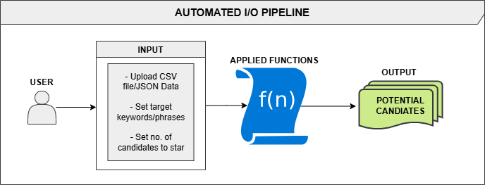

**INPUT** : The client/user is required to only set three inputs:

- The CSV/JSON file in this consistent format - id, job_title, location, connection - [*Must be ensured by the client]
- Set target keywords, such as "Aspiring Human Resources", "Seeking Human Resources" - It can be updated as per requirement
- How many candidates to star? Can star only 1 or even multiple candidates

**OUTPUT** : The client will recieve a list of potential candidates based on the ranking algorithm inbuilt with dedicated functions.

### FUTURE SCALABILITY

- The pipeline can be easily extended to other job roles by modifying the target keywords.
- The feedback mechanism and thresholding approach are role-agnostic, making the system scalable across departments.
- Since the algorithm is fully functional, it can be integrated into HR dashboards or web-based ATS systems for real-time candidate shortlisting.